# Marketing Strategies Review

2022-07-14

## Reading Data

First 6 rows of the data table.

```r
raw_sales_data = as.data.frame(read.csv("data_20160405.csv"))
head(raw_sales_data)
```

```
##   X      accID  accType accSize accTargets district    month   sales qty
## 1 1 XYZ-987002 Pharmacy     700         25        3 01-10-13       0   0
## 2 2 XYZ-987002 Pharmacy     700         25        3 01-11-13  852365   8
## 3 3 XYZ-987002 Pharmacy     700         25        3 01-12-13 2557096  25
## 4 4 XYZ-987002 Pharmacy     700         25        3 01-01-14 4261826  41
## 5 5 XYZ-987002 Pharmacy     700         25        3 01-02-14 5966556  57
## 6 6 XYZ-987002 Pharmacy     700         25        3 01-03-14 6818921  66
##   strategy1 strategy2 strategy3 salesVisit1 salesVisit2 salesVisit3 salesVisit4
## 1         0         0         0           0           0           0           0
## 2         0         0         0           0           0           0           0
## 3         0         0         0           0           0           0           0
## 4         0         0         0           0      825000      300000           0
## 5         0         0         0           0           0           0           0
## 6         0         0         0           0     1050000       75000           0
##   salesVisit5 compBrand
## 1           0         4
## 2       75000         4
## 3           0         4
## 4           0         4
## 5           0         4
## 6           0         4
```

## Missing values

Number of missing values in each column

```
##           X       accID     accType     accSize  accTargets    district
##           0           0           0           0           0           0
##       month       sales         qty   strategy1   strategy2   strategy3
##           0           0           0           0           0           0
## salesVisit1 salesVisit2 salesVisit3 salesVisit4 salesVisit5   compBrand
##           0           0           0           0           0           0
```

## Data preprocessing

There are 14 independent variables: 1. 3 categorical variables. 2. 10 numerical variables. 3. 1 date variable.

### Categorical variables

Converting account type variable to dummies.

```r
library(fastDummies)
library(knitr)

acc_type = data.frame(accType = raw_sales_data$accType)
acc_type_dummy = dummy_cols(acc_type)
acc_type_dummy = acc_type_dummy[, -1]
head(acc_type_dummy)
```

```
##   accType_Hospital accType_Pharmacy accType_Polyclinic accType_Private Clinic
## 1                0                1                  0                      0
## 2                0                1                  0                      0
## 3                0                1                  0                      0
## 4                0                1                  0                      0
## 5                0                1                  0                      0
## 6                0                1                  0                      0
```

Since there is only 1 district(3), we are going to ignore this variable.

```r
print(paste("Unique district vales:", unique(raw_sales_data$district)))
```

```
## [1] "Unique district vales: 3"
```

Convert Competitive brands variable to binary.

```r
comp_brand = data.frame(accType = raw_sales_data$compBrand)
comp_brand_dummy = dummy_cols(comp_brand)
comp_brand_dummy = comp_brand_dummy[, -1]
head(comp_brand_dummy)
```

```
##   accType_4 accType_5
## 1         1         0
## 2         1         0
## 3         1         0
## 4         1         0
## 5         1         0
## 6         1         0
```

### Numerical variables

As we can see from the correlation plot account size and account target are highly correlated. We should drop one of these variables.

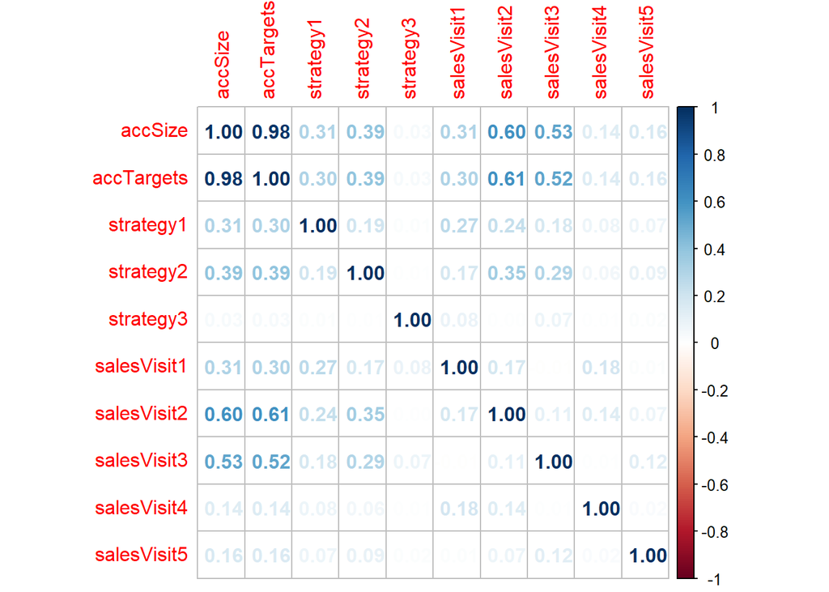

```r
library(corrplot)
numerical_columns = colnames(raw_sales_data)[!colnames(raw_sales_data) %in% c("X", "accID", "accType","district", "compBrand", "sales", "qty", "month")]
cormatrix = cor(raw_sales_data[numerical_columns] )
corrplot(cormatrix, method = "number")
```

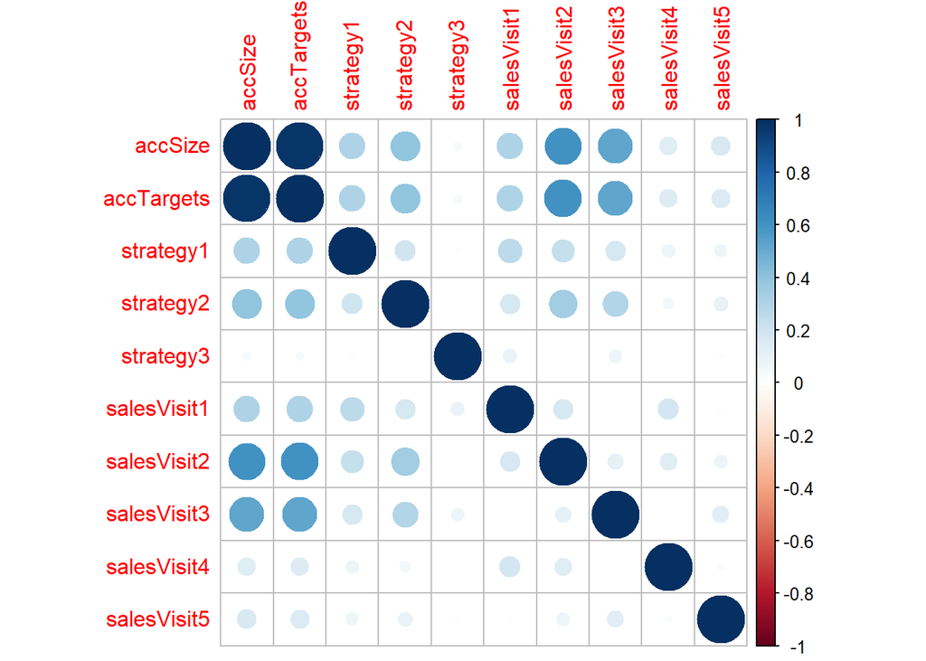

```r
corrplot(cormatrix, method = "circle")
```

### Standardization of numeric variables We need to scale the numeric variables and remove account targets

```r
numerical_columns_data = raw_sales_data[numerical_columns]
scaled_numerical_columns_data = scale(numerical_columns_data)

# Removing account size
scaled_numerical_columns_data = subset(scaled_numerical_columns_data, select = -c(accTargets) )
head(scaled_numerical_columns_data)
```

```
##        accSize  strategy1 strategy2   strategy3 salesVisit1 salesVisit2
## [1,] 0.8043031 -0.1981688 -0.396749 -0.07770456  -0.1269137  -0.5956210
## [2,] 0.8043031 -0.1981688 -0.396749 -0.07770456  -0.1269137  -0.5956210
## [3,] 0.8043031 -0.1981688 -0.396749 -0.07770456  -0.1269137  -0.5956210
## [4,] 0.8043031 -0.1981688 -0.396749 -0.07770456  -0.1269137   0.4486856
## [5,] 0.8043031 -0.1981688 -0.396749 -0.07770456  -0.1269137  -0.5956210
## [6,] 0.8043031 -0.1981688 -0.396749 -0.07770456  -0.1269137   0.7334965
##      salesVisit3 salesVisit4 salesVisit5
## [1,]  -0.5708616  -0.1828577  -0.1642669
## [2,]  -0.5708616  -0.1828577   3.4569055
## [3,]  -0.5708616  -0.1828577  -0.1642669
## [4,]  -0.1765288  -0.1828577  -0.1642669
## [5,]  -0.5708616  -0.1828577  -0.1642669
## [6,]  -0.4722784  -0.1828577  -0.1642669
```

### Converting date variable into 2 variables of month and year

Month can have significant impact on sales if sales are seasonal. Year can be useful if there are any yearly changes in sales.

```r
date_data        = as.POSIXct(raw_sales_data$month)
data_month       = data.frame(month = format(date_data,"%B") )
data_month_dummy = dummy_cols(data_month)
data_month_dummy = data_month_dummy[, -1]

data_year       = data.frame(year = as.numeric(format(date_data,"%Y") ) )
data_year       = data_year - min(data_year)

date_data_transformed =   cbind(data_month_dummy, data_year)
head(date_data_transformed, 10)
```

```
##    month_April month_August month_December month_February month_January
## 1            0            0              0              0             0
## 2            0            0              0              0             0
## 3            0            0              1              0             0
## 4            0            0              0              0             1
## 5            0            0              0              1             0
## 6            0            0              0              0             0
## 7            1            0              0              0             0
## 8            0            0              0              0             0
## 9            0            0              0              0             0
## 10           0            0              0              0             0
##    month_July month_June month_March month_May month_November month_October
## 1           0          0           0         0              0             1
## 2           0          0           0         0              1             0
## 3           0          0           0         0              0             0
```

[output cut: 18 more lines]

### Checking correlation of dependent variables

Quantity and sales have correlation of 1. It means we need to consider only 1 of these.

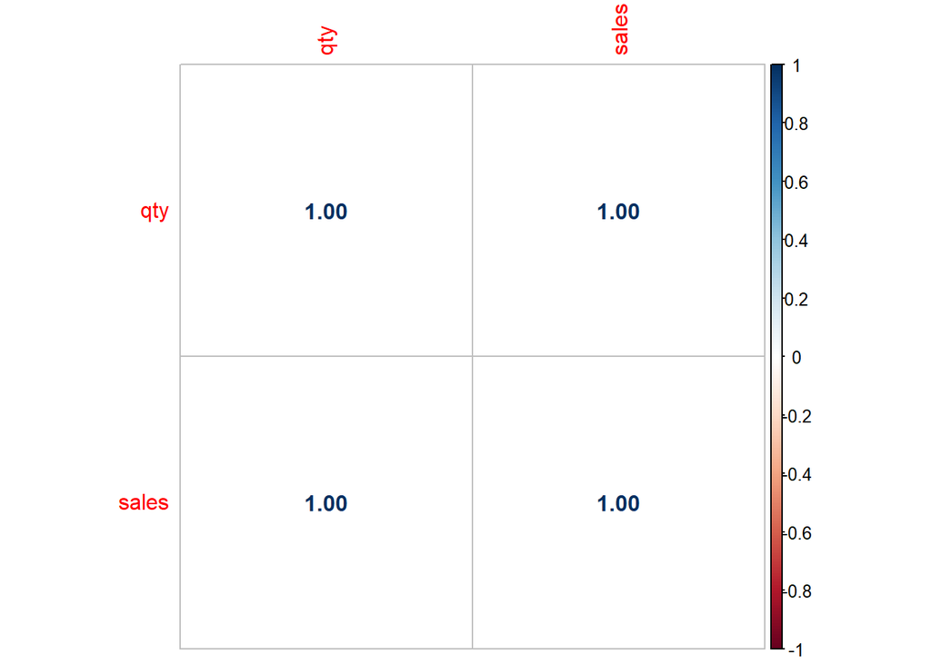

```r
dependent_data = raw_sales_data[, c("qty", "sales")]
cormatrix = cor(dependent_data)
corrplot(cormatrix, method = "number")
```

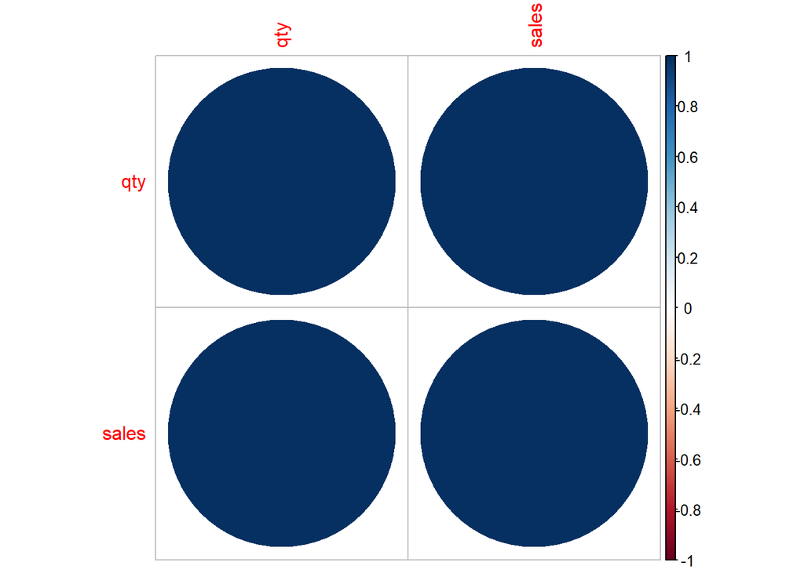

```r
corrplot(cormatrix, method = "circle")
```

### Distributioin of sales variable

There are some negative sales value. Maybe the customer returned some product that was either defective or was not used by the customer. We need to change these values to 0. Any strategy cannot have negative effect on the sales.

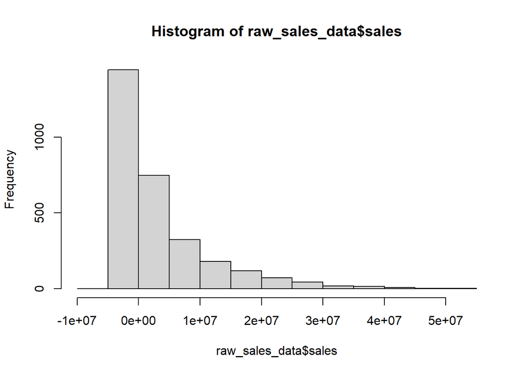

```r
hist(raw_sales_data$sales)
```

### New variable related to sales

We can create another dependent variable to mark whether sales have happened or not. This will be 0 if sales is 0 otherwise it will be 1.

```r
sales_happened = data.frame(sales_happened = ifelse(raw_sales_data$sales > 0, 1, 0) )
head(sales_happened, 10)
```

```
##    sales_happened
## 1               0
## 2               1
## 3               1
## 4               1
## 5               1
## 6               1
## 7               1
## 8               1
## 9               1
## 10              1
```

### Creating dataframe of predictors.

For categorical variables with more than 2 alternatives first column will be removed. If there are n alternatives for a categorical variable, n-1 columns are required to represent that variable.

```r
acc_type_variable = acc_type_dummy[, -1]
comp_brand_variable = comp_brand_dummy[, -1]
date_data_variable  = date_data_transformed[colnames(date_data_transformed) != "month_April"]

logistic_data = cbind(acc_type_variable, comp_brand_variable, date_data_variable, scaled_numerical_columns_data, sales_happened)

head(logistic_data)
```

```
##   accType_Pharmacy accType_Polyclinic accType_Private Clinic
## 1                1                  0                      0
## 2                1                  0                      0
## 3                1                  0                      0
## 4                1                  0                      0
## 5                1                  0                      0
## 6                1                  0                      0
##   comp_brand_variable month_August month_December month_February month_January
## 1                   0            0              0              0             0
## 2                   0            0              0              0             0
## 3                   0            0              1              0             0
## 4                   0            0              0              0             1
## 5                   0            0              0              1             0
## 6                   0            0              0              0             0
##   month_July month_June month_March month_May month_November month_October
```

[output cut: 20 more lines]

### Logistic model to identify the influence of predictors on whether sale will happen or not.

```r
library(nnet)

logistic_model = multinom(formula = sales_happened ~ ., data = logistic_data)
results_log = data.frame(coefficients = summary(logistic_model)$coefficients)
results_log$stdev        = summary(logistic_model)$standard.errors
results_log$zvalues      = results_log$coefficients / results_log$stdev
results_log$pvalues      = 2 * pnorm(-abs(results_log$zvalues) )

results_log = results_log[order(-abs(results_log$coefficients)),  ]
results_log
```

```
##                          coefficients      stdev     zvalues      pvalues
## comp_brand_variable        1.56753571 0.17421921  8.99749080 2.309352e-19
## accType_Polyclinic        -1.15488114 0.12585992 -9.17592444 4.477162e-20
## salesVisit2                0.84429209 0.10171406  8.30064277 1.035496e-16
## `accType_Private Clinic`  -0.81981224 0.17669492 -4.63970470 3.489074e-06
## accSize                    0.80400366 0.11269605  7.13426634 9.730476e-13
## (Intercept)                0.77842589 0.18008577  4.32252854 1.542511e-05
## salesVisit3                0.66124001 0.09104173  7.26304339 3.784765e-13
## salesVisit1                0.64687362 0.22075009  2.93034359 3.385874e-03
## month_October             -0.39527818 0.24704048 -1.60005426 1.095865e-01
## month_June                -0.38167766 0.25462622 -1.49897232 1.338808e-01
## strategy2                  0.35754590 0.08428396  4.24215808 2.213807e-05
## month_March               -0.34005730 0.24427153 -1.39212822 1.638836e-01
## accType_Pharmacy          -0.31276857 0.18215033 -1.71709039 8.596266e-02
## month_May                  0.28531002 0.23889188  1.19430606 2.323583e-01
## month_September            0.24115830 0.25414198  0.94891170 3.426655e-01
## month_February            -0.23780861 0.24018507 -0.99010571 3.221225e-01
## month_November            -0.23209088 0.24351734 -0.95307744 3.405508e-01
## month_July                -0.22040066 0.25813546 -0.85381783 3.932059e-01
## month_January             -0.19429592 0.24020587 -0.80887251 4.185885e-01
## strategy3                  0.17236882 0.14401308  1.19689701 2.313467e-01
## salesVisit5                0.07273077 0.05888656  1.23509965 2.167934e-01
## salesVisit4                0.05706541 0.06275946  0.90927183 3.632067e-01
## strategy1                  0.04580250 0.07815365  0.58605708 5.578372e-01
## month_December             0.03721688 0.23963811  0.15530453 8.765812e-01
## month_August               0.01084453 0.25594255  0.04237096 9.662030e-01
## year                       0.00000000        NaN         NaN          NaN
```

### Confusian matrix of logistic model

```r
# Predicting on test data'
prediction = predict(logistic_model, newdata = logistic_data)

# Confusion Matrix
cm = table(logistic_data$sales_happened, prediction)
cm
```

```
##    prediction
##        0    1
##   0 1179  264
##   1  350 1183
```

### Strategy results

Effect of strategy on probability of sales.

```r
strategy_results = results_log[c("strategy1", "strategy2", "strategy3"),  ]
strategy_results
```

```
##           coefficients      stdev   zvalues      pvalues
## strategy1    0.0458025 0.07815365 0.5860571 5.578372e-01
## strategy2    0.3575459 0.08428396 4.2421581 2.213807e-05
## strategy3    0.1723688 0.14401308 1.1968970 2.313467e-01
```

### Effect of new entrant on probability sales

```r
new_entrant_results = results_log[c("comp_brand_variable"),  ]
new_entrant_results
```

```
##                     coefficients     stdev  zvalues      pvalues
## comp_brand_variable     1.567536 0.1742192 8.997491 2.309352e-19
```

```r
new_entrant_data = logistic_data[logistic_data$comp_brand_variable == 1, ]

new_entrant_prediction = predict(logistic_model, newdata = new_entrant_data, type = "prob")

without_new_entrant_data = new_entrant_data
without_new_entrant_data$comp_brand_variable = 0

without_new_entrant_prediction = predict(logistic_model, newdata = without_new_entrant_data, type = "prob")

change_in_prob = (mean(new_entrant_prediction) - mean(without_new_entrant_prediction)) / mean(without_new_entrant_prediction) * 100

change_in_prob
```

```
## [1] 44.59279
```

```r
data.frame(Condition = c("Without new competitor", "With new competitor"),
           `Average Probability` = c(mean(without_new_entrant_prediction), mean(new_entrant_prediction) )  )
```

```
##                Condition Average.Probability
## 1 Without new competitor           0.5033603
## 2    With new competitor           0.7278227
```

### Creating data for linear regression on cases where sale has happened

```r
log_sales = data.frame(sales = raw_sales_data$sales[logistic_model$fitted.values > 0.5] )


linear_data = cbind(logistic_data[logistic_model$fitted.values > 0.5, ], log_sales)
linear_data$sales[linear_data$sales < 0] = 0
linear_data = linear_data[, colnames(linear_data) != "sales_happened"]
head(linear_data)
```

```
##   accType_Pharmacy accType_Polyclinic accType_Private Clinic
## 3                1                  0                      0
## 4                1                  0                      0
## 6                1                  0                      0
## 7                1                  0                      0
## 8                1                  0                      0
## 9                1                  0                      0
##   comp_brand_variable month_August month_December month_February month_January
## 3                   0            0              1              0             0
## 4                   0            0              0              0             1
## 6                   0            0              0              0             0
## 7                   0            0              0              0             0
## 8                   0            0              0              0             0
## 9                   0            0              0              0             0
##   month_July month_June month_March month_May month_November month_October
```

[output cut: 20 more lines]

### Linear regression model

```r
linear_model = lm(formula = sales ~ ., data = linear_data)

results = data.frame(coefficients = summary(linear_model)$coefficients)
results = results[order(-abs(results$coefficients.Estimate)),  ]
results
```

```
##                          coefficients.Estimate coefficients.Std..Error
## comp_brand_variable                6127424.699                605159.8
## accType_Polyclinic                -5228143.512               1054740.5
## (Intercept)                        4625247.407                641091.5
## `accType_Private Clinic`          -2772844.312               1265493.5
## month_August                      -2534567.093                907813.7
## month_June                        -2454156.867                947166.8
## salesVisit2                        2301362.831                197186.1
## month_July                        -2236559.764                908900.6
## accSize                            2183982.914                305281.1
## accType_Pharmacy                  -2024684.759                572118.7
## month_March                       -2009403.182                885384.3
## month_October                     -1797405.455               1053371.7
## salesVisit3                        1351349.079                189760.0
## month_September                   -1319307.491                892955.8
## month_February                    -1265303.420                911336.1
## strategy2                          1240831.007                151917.9
## month_December                     1226393.169                967791.4
## salesVisit4                         999087.787                134596.3
## salesVisit1                         659324.437                148232.1
## month_November                     -233640.935               1017853.9
## month_May                          -166917.488                865229.2
## strategy1                           158818.676                143833.2
## month_January                        54362.077                942965.8
## strategy3                            20215.671                133509.5
## salesVisit5                          -2773.849                137807.3
##                          coefficients.t.value coefficients.Pr...t..
## comp_brand_variable               10.12530042          2.576648e-23
## accType_Polyclinic                -4.95680559          8.026343e-07
## (Intercept)                        7.21464513          8.763665e-13
## `accType_Private Clinic`          -2.19111695          2.860512e-02
## month_August                      -2.79194634          5.309324e-03
## month_June                        -2.59105041          9.666251e-03
## salesVisit2                       11.67101686          4.031856e-30
## month_July                        -2.46073078          1.398357e-02
## accSize                            7.15400523          1.344837e-12
## accType_Pharmacy                  -3.53892411          4.146987e-04
## month_March                       -2.26952659          2.338552e-02
## month_October                     -1.70633540          8.816400e-02
## salesVisit3                        7.12135811          1.691286e-12
## month_September                   -1.47746111          1.397735e-01
## month_February                    -1.38840474          1.652313e-01
## strategy2                          8.16777119          6.863630e-16
## month_December                     1.26720817          2.052884e-01
## salesVisit4                        7.42284898          1.965417e-13
## salesVisit1                        4.44791815          9.345635e-06
## month_November                    -0.22954270          8.184801e-01
## month_May                         -0.19291708          8.470515e-01
## strategy1                          1.10418683          2.696989e-01
## month_January                      0.05765010          9.540354e-01
## strategy3                          0.15141743          8.796679e-01
## salesVisit5                       -0.02012847          9.839437e-01
```

### Linear model tests

```r
library(olsrr)
ols_test_normality(linear_model)
```

```
## -----------------------------------------------
##        Test             Statistic       pvalue
## -----------------------------------------------
## Shapiro-Wilk              0.9348         0.0000
## Kolmogorov-Smirnov        0.1018         0.0000
## Cramer-von Mises         134.2255        0.0000
## Anderson-Darling         28.5071         0.0000
## -----------------------------------------------
```

### Strategy results

```r
strategy_results = results[c("strategy1", "strategy2", "strategy3"), ]
strategy_results
```

```
##           coefficients.Estimate coefficients.Std..Error coefficients.t.value
## strategy1             158818.68                143833.2            1.1041868
## strategy2            1240831.01                151917.9            8.1677712
## strategy3              20215.67                133509.5            0.1514174
##           coefficients.Pr...t..
## strategy1          2.696989e-01
## strategy2          6.863630e-16
## strategy3          8.796679e-01
```

### Effect of new entrant on sales

```r
new_entrant_results = results[c("comp_brand_variable"),  ]
new_entrant_results
```

```
##                     coefficients.Estimate coefficients.Std..Error
## comp_brand_variable               6127425                605159.8
##                     coefficients.t.value coefficients.Pr...t..
## comp_brand_variable              10.1253          2.576648e-23
```

```r
new_entrant_data_linear = linear_data[linear_data$comp_brand_variable == 1, ]

new_entrant_prediction_sales = predict(linear_model, newdata = new_entrant_data_linear, type = "response")
without_new_entrant_data_linear = new_entrant_data_linear
without_new_entrant_data_linear$comp_brand_variable = 0

without_new_entrant_prediction_sales = predict(linear_model, newdata = without_new_entrant_data_linear, type = "response")
change_in_sales = (mean(new_entrant_prediction_sales) - mean(without_new_entrant_prediction_sales)) / mean(without_new_entrant_prediction_sales) * 100

change_in_sales
```

```
## [1] 161.4796
```

```r
data.frame(Condition = c("Without new competitor", "With new competitor"),
           `Average Sales` = c(mean(without_new_entrant_prediction_sales), mean(new_entrant_prediction_sales) )  )
```

```
##                Condition Average.Sales
## 1 Without new competitor       3794551
## 2    With new competitor       9921976
```

### Increase in sales by increasing expenditure on strategy 1 by 1%

```r
scaled_increased_variable = function(variable) {
    mean_variable = mean(variable)
    sd_variable   = sd(variable)

    increased_variable        = variable * 1.01
    scaled_increased_variable = (increased_variable - mean_variable) / sd_variable

    return(scaled_increased_variable)
}

mean_sales_predicted = mean(linear_model$fitted.values)

# Increase in sales by increasing expenditure in strategy 1 by 1%
scaled_increased_s1 = scaled_increased_variable(numerical_columns_data$strategy1)

linear_data_s1_increased = linear_data
linear_data_s1_increased$strategy1 = scaled_increased_s1[logistic_model$fitted.values > 0.5]

sales_predicted_increased_s1 = predict(object = linear_model, newdata = linear_data_s1_increased)
mean_sales_predicted_increased_s1 =  mean(sales_predicted_increased_s1)

increased_sales_increased_s1 = (mean_sales_predicted_increased_s1 - mean_sales_predicted) / mean_sales_predicted

# Increase in sales by increasing expenditure in strategy 2 by 1%
scaled_increased_s2 = scaled_increased_variable(numerical_columns_data$strategy2)

linear_data_s2_increased = linear_data
linear_data_s2_increased$strategy2 = scaled_increased_s2[logistic_model$fitted.values > 0.5]

sales_predicted_increased_s2 = predict(object = linear_model, newdata = linear_data_s2_increased)
mean_sales_predicted_increased_s2 =  mean(sales_predicted_increased_s2)

increased_sales_increased_s2 = (mean_sales_predicted_increased_s2 - mean_sales_predicted) / mean_sales_predicted

# Increase in sales by increasing expenditure in strategy 3 by 1%
scaled_increased_s3 = scaled_increased_variable(numerical_columns_data$strategy3)

linear_data_s3_increased = linear_data
linear_data_s3_increased$strategy3 = scaled_increased_s3[logistic_model$fitted.values > 0.5]

sales_predicted_increased_s3 = predict(object = linear_model, newdata = linear_data_s3_increased)
mean_sales_predicted_increased_s3 =  mean(sales_predicted_increased_s3)

increased_sales_increased_s3 = (mean_sales_predicted_increased_s3 - mean_sales_predicted) / mean_sales_predicted




sale_increase_by_strategy = data.frame(strategy = c("Strategy 1", "Strategy 2", "Strategy 3"),
                                  `Increase in sales (%)` = c(increased_sales_increased_s1, increased_sales_increased_s2,
                                                          increased_sales_increased_s3) *100, check.names = FALSE  )
sale_increase_by_strategy
```

```
##     strategy Increase in sales (%)
## 1 Strategy 1          0.0076091887
## 2 Strategy 2          0.1202930320
## 3 Strategy 3          0.0004027859
```

### Increase in probability of sales by increasing expenditure of each strategy by 1% (one at a time)

```r
mean_prob_predicted       = mean(logistic_model$fitted.values)

# Increase in probability of sales by increasing expenditure in strategy 1 by 1%
logistic_data_s1_increased = logistic_data
logistic_data_s1_increased$strategy1 = scaled_increased_s1

prob_predicted_increased_s1 = predict(object = logistic_model, newdata = logistic_data_s1_increased, type = "prob")
mean_prob_predicted_increased_s1 =  mean(prob_predicted_increased_s1)

increased_prob_increased_s1 = (mean_prob_predicted_increased_s1 - mean_prob_predicted) / mean_prob_predicted

# Increase in probability of sales by increasing expenditure in strategy 2 by 1%
logistic_data_s2_increased = logistic_data
logistic_data_s2_increased$strategy2 = scaled_increased_s2

prob_predicted_increased_s2 = predict(object = logistic_model, newdata = logistic_data_s2_increased, type = "prob")
mean_prob_predicted_increased_s2 =  mean(prob_predicted_increased_s2)

increased_prob_increased_s2 = (mean_prob_predicted_increased_s2 - mean_prob_predicted) / mean_prob_predicted

# Increase in probability of sales by increasing expenditure in strategy 2 by 1%
logistic_data_s3_increased = logistic_data
logistic_data_s3_increased$strategy3 = scaled_increased_s3

prob_predicted_increased_s3 = predict(object = logistic_model, newdata = logistic_data_s3_increased, type = "prob")
mean_prob_predicted_increased_s3 =  mean(prob_predicted_increased_s3)

increased_prob_increased_s3 = (mean_prob_predicted_increased_s3 - mean_prob_predicted) / mean_prob_predicted

prob_increase_by_strategy = data.frame(strategy = c("Strategy 1", "Strategy 2", "Strategy 3"),
                                  `Increase in probability of sale (%)` = c(increased_prob_increased_s1,
                                                                             increased_prob_increased_s2,
                                                                             increased_prob_increased_s3) *100,
                                  check.names = FALSE  )
prob_increase_by_strategy
```

```
##     strategy Increase in probability of sale (%)
## 1 Strategy 1                        0.0013614076
## 2 Strategy 2                        0.0187656498
## 3 Strategy 3                        0.0008654806
```

### Regression of each account ID

```r
account_ids = unique(raw_sales_data$accID)

new_d = cbind(logistic_data, sales = raw_sales_data$sales)
new_d = new_d[, colnames(new_d) != "sales_happened"]
new_d$sales[new_d$sales < 0] = 0

coeff_matrix = matrix(NA, nrow = length(account_ids), ncol = 3)
rownames(coeff_matrix) = account_ids
colnames(coeff_matrix) = c("1 coefficient", "2 coefficient", "3 coefficient")

pvalue_matrix = matrix(NA, nrow = length(account_ids), ncol = 3)
rownames(pvalue_matrix) = account_ids
colnames(pvalue_matrix) = c("1 p-value", "2 p-value", "3 p-value")


for(a in 1:length(account_ids) ) {
  ac_data = new_d[raw_sales_data$accID == as.character(account_ids[a]), ]
  drop = NULL
  for (c in 1:ncol(ac_data) ) {
    if (length(unique(ac_data[, c] ) ) == 1 )
      drop = c(drop, c)
  }
  ac_data = ac_data[, -drop]

  ac_model = lm(formula = sales ~ ., data = ac_data)

  m_summary = summary(ac_model)$coefficients

  if ("strategy1" %in% rownames(m_summary) ) {
    coeff_matrix[a, 1 ] = c(m_summary["strategy1", 1] )
    pvalue_matrix[a, 1 ] = c(m_summary["strategy1", 4] )
  }
  if ("strategy2" %in% rownames(m_summary) ) {
    coeff_matrix[a, 2 ] = c(m_summary["strategy2", 1] )
    pvalue_matrix[a, 2 ] = c(m_summary["strategy2", 4] )
  }
  if ("strategy3" %in% rownames(m_summary) ) {
    coeff_matrix[a, 3 ] = c(m_summary["strategy3", 1] )
    pvalue_matrix[a, 3 ] = c(m_summary["strategy3", 4] )
  }

}
head(coeff_matrix)
```

```
##            1 coefficient 2 coefficient 3 coefficient
## XYZ-987002       3967918     1503745.3            NA
## XYZ-987005       4910557      971457.5            NA
## XYZ-987006      -4969514     -387764.7            NA
## XYZ-987007       7270050     7626424.5            NA
## XYZ-987008      -1695666     3489203.0            NA
## XYZ-987009       3361677     1185798.7            NA
```

```r
head(pvalue_matrix)
```

```
##             1 p-value  2 p-value 3 p-value
## XYZ-987002 0.67550916 0.14810405        NA
## XYZ-987005 0.74068451 0.88952908        NA
## XYZ-987006 0.04072497 0.62234879        NA
## XYZ-987007 0.02103019 0.04041024        NA
## XYZ-987008 0.67359894 0.54560341        NA
## XYZ-987009 0.23651807 0.21549262        NA
```

### Best strategy for each client

```r
best_strategy = coeff_matrix
#best_strategy[is.na(best_strategy)] = -Inf

bs = as.matrix(apply(best_strategy, 1, max, na.rm = TRUE) )
bs_result = NULL

for (r in 1:nrow(best_strategy) ) {
  bs_value  = max(best_strategy[r, ], na.rm = TRUE )
  bs_result = c(bs_result, match(bs_value, best_strategy[r, ] ) )

}
```

[output not shown]

```r
bs_result_data_frame = data.frame(accID = rownames(best_strategy), `Best strategy` = paste("Strategy", bs_result), check.names = FALSE )

bs_result_data_frame
```

```
##          accID Best strategy
## 1   XYZ-987002    Strategy 1
## 2   XYZ-987005    Strategy 1
## 3   XYZ-987006    Strategy 2
## 4   XYZ-987007    Strategy 2
## 5   XYZ-987008    Strategy 2
## 6   XYZ-987009    Strategy 1
## 7   XYZ-987010    Strategy 2
## 8   XYZ-987014   Strategy NA
## 9   XYZ-987015    Strategy 1
## 10  XYZ-987016    Strategy 1
## 11  XYZ-987017    Strategy 2
## 12  XYZ-987019    Strategy 2
## 13  XYZ-987021    Strategy 3
## 14  XYZ-987022    Strategy 2
```

[output cut: 110 more lines]

### Distribution of best strategy

```r
table(bs_result_data_frame$`Best strategy`)
```

```
##
##  Strategy 1  Strategy 2  Strategy 3 Strategy NA
##          32          67          11          14
```

### Characteristics of accounts that are influenced most by strategy 1

```r
s_accounts = function(strategy) {

  s1_accounts = bs_result_data_frame[bs_result_data_frame$`Best strategy` == strategy, ]

  s1_accounts$acc_type = NA
  s1_accounts$acc_size = NA
  s1_accounts$avg_sales = NA

  for (r in 1:nrow(s1_accounts) ) {

  s1_accounts$acc_type[r] = unique(raw_sales_data$accType[raw_sales_data$accID == s1_accounts$accID[r] ])
  s1_accounts$acc_size[r] = mean(raw_sales_data$accSize[raw_sales_data$accID == s1_accounts$accID[r] ])
  s1_accounts$avg_sales[r] = mean(raw_sales_data$sales[raw_sales_data$accID == s1_accounts$accID[r] ])
  }

  return(s1_accounts)

}

s1_accounts = s_accounts("Strategy 1")
s1_accounts
```

```
##          accID Best strategy       acc_type acc_size   avg_sales
## 1   XYZ-987002    Strategy 1       Pharmacy      700  6641345.42
## 2   XYZ-987005    Strategy 1       Hospital      790 15324815.71
## 6   XYZ-987009    Strategy 1       Pharmacy      520  3196369.46
## 9   XYZ-987015    Strategy 1       Hospital      210  4865584.71
## 10  XYZ-987016    Strategy 1       Hospital      200   248606.46
## 17  XYZ-987025    Strategy 1       Hospital      790 11613475.54
## 18  XYZ-987026    Strategy 1       Hospital      350  2113155.38
## 21  XYZ-987030    Strategy 1 Private Clinic       50   461697.75
## 22  XYZ-987032    Strategy 1 Private Clinic       30    35515.21
## 23  XYZ-987033    Strategy 1       Hospital       50  1349578.21
## 24  XYZ-987034    Strategy 1       Hospital       30    35515.21
## 30  XYZ-987045    Strategy 1       Hospital      370   461697.75
## 32  XYZ-987049    Strategy 1     Polyclinic      579  2379519.46
## 35  XYZ-987054    Strategy 1       Hospital      310  3764612.92
```

[output cut: 18 more lines]

### Characteristics of accounts that are influenced most by strategy 2

```r
s2_accounts = s_accounts("Strategy 2")
s2_accounts
```

```
##          accID Best strategy       acc_type acc_size   avg_sales
## 3   XYZ-987006    Strategy 2       Hospital      320  4350613.92
## 4   XYZ-987007    Strategy 2       Pharmacy     1000 16194938.46
## 5   XYZ-987008    Strategy 2       Hospital      440 13664479.25
## 7   XYZ-987010    Strategy 2       Hospital      670  5860010.67
## 11  XYZ-987017    Strategy 2       Hospital      680 13730182.54
## 12  XYZ-987019    Strategy 2       Hospital       60  3054308.62
## 14  XYZ-987022    Strategy 2       Hospital      420   142060.83
## 15  XYZ-987023    Strategy 2       Pharmacy      720  4563705.38
## 16  XYZ-987024    Strategy 2 Private Clinic      520  3196369.33
## 19  XYZ-987027    Strategy 2       Hospital      380  8772258.33
## 20  XYZ-987029    Strategy 2       Hospital      300  1988852.12
## 26  XYZ-987036    Strategy 2       Hospital      130  1029941.25
## 28  XYZ-987039    Strategy 2       Hospital       30   497212.96
## 29  XYZ-987043    Strategy 2       Hospital      640  9482562.58
```

[output cut: 53 more lines]

### Characteristics of accounts that are influenced most by strategy 3

```r
s3_accounts = s_accounts("Strategy 3")
s3_accounts
```

```
##          accID Best strategy       acc_type acc_size   avg_sales
## 13  XYZ-987021    Strategy 3       Pharmacy      580  5025403.12
## 25  XYZ-987035    Strategy 3       Hospital       60    88788.04
## 27  XYZ-987037    Strategy 3       Hospital      300  2193064.50
## 34  XYZ-987052    Strategy 3       Hospital      200  1136486.79
## 46  XYZ-987071    Strategy 3       Pharmacy     1026 10175109.29
## 80  XYZ-987124    Strategy 3 Private Clinic       50    35515.21
## 85  XYZ-987135    Strategy 3       Hospital      420  8559167.00
## 101 XYZ-987156    Strategy 3       Pharmacy      965 17722092.62
## 105 XYZ-987163    Strategy 3       Hospital      360  1243032.67
## 107 XYZ-987165    Strategy 3       Hospital      350  4199674.25
## 111 XYZ-987172    Strategy 3       Pharmacy     2460 21664281.67
```

### Characteristics of accounts that are influenced most by strategy NA

```r
s4_accounts = s_accounts("Strategy NA")
s4_accounts
```

```
##          accID Best strategy       acc_type acc_size avg_sales
## 8   XYZ-987014   Strategy NA     Polyclinic      240 213091.29
## 31  XYZ-987047   Strategy NA Private Clinic       10  71030.42
## 38  XYZ-987060   Strategy NA     Polyclinic       60  71030.42
## 60  XYZ-987091   Strategy NA     Polyclinic      180 781334.58
## 62  XYZ-987093   Strategy NA     Polyclinic       80 355152.08
## 63  XYZ-987095   Strategy NA     Polyclinic       60  71030.42
## 70  XYZ-987106   Strategy NA     Polyclinic       30 461697.71
## 74  XYZ-987112   Strategy NA Private Clinic       50  71030.42
## 75  XYZ-987113   Strategy NA Private Clinic       10 106545.62
## 79  XYZ-987121   Strategy NA     Polyclinic       10  71030.42
## 100 XYZ-987153   Strategy NA     Polyclinic       60  71030.42
## 102 XYZ-987157   Strategy NA       Hospital      350 728061.83
## 110 XYZ-987170   Strategy NA       Hospital       50 106545.62
## 122 XYZ-987187   Strategy NA     Polyclinic       20  35515.21
```

### Matrix of best strategy

```r
acc_type_s1 = table(s1_accounts$acc_type)
acc_type_s2 = table(s2_accounts$acc_type)
acc_type_s3 = table(s3_accounts$acc_type)
acc_type_s4 = table(s4_accounts$acc_type)

acc_matrix = matrix(0, nrow = 4, ncol = 4)
colnames(acc_matrix) = c("Hospital", "Pharmacy", "Polyclinic", "Private Clinic")
rownames(acc_matrix) = c("Strategy 1", "Strategy 2", "Strategy 3", "Strategy NA")

acc_matrix["Strategy 1", ]  = acc_type_s1[c("Hospital", "Pharmacy", "Polyclinic", "Private Clinic")]
acc_matrix["Strategy 2", ]  = acc_type_s2[c("Hospital", "Pharmacy", "Polyclinic", "Private Clinic")]
acc_matrix["Strategy 3", ]  = acc_type_s3[c("Hospital", "Pharmacy", "Polyclinic", "Private Clinic")]
acc_matrix["Strategy NA", ] = acc_type_s4[c("Hospital", "Pharmacy", "Polyclinic", "Private Clinic")]

acc_matrix[is.na(acc_matrix) ] = 0
acc_matrix
```

```
##             Hospital Pharmacy Polyclinic Private Clinic
## Strategy 1        19        5          6              2
## Strategy 2        30       12         20              5
## Strategy 3         6        4          0              1
## Strategy NA        2        0          9              3
```

### Matrix of percentage of best strategy

```r
acc_matrix_percent = acc_matrix

for (c in 1:ncol(acc_matrix) ) {
  acc_matrix_percent[, c] = acc_matrix[, c] / sum(acc_matrix[, c] )
}
acc_matrix_percent
```

```
##               Hospital  Pharmacy Polyclinic Private Clinic
## Strategy 1  0.33333333 0.2380952  0.1714286     0.18181818
## Strategy 2  0.52631579 0.5714286  0.5714286     0.45454545
## Strategy 3  0.10526316 0.1904762  0.0000000     0.09090909
## Strategy NA 0.03508772 0.0000000  0.2571429     0.27272727
```

```r
library("formattable")

percent(acc_matrix_percent)
```

```
##             Hospital Pharmacy Polyclinic Private Clinic
## Strategy 1  33.33%   23.81%   17.14%     18.18%
## Strategy 2  52.63%   57.14%   57.14%     45.45%
## Strategy 3  10.53%   19.05%   0.00%      9.09%
## Strategy NA 3.51%    0.00%    25.71%     27.27%
```